# Single Cell V(D)J Analysis

UCD Bioinformatics Core

Last Updated June 22, 2023

# Single Cell V(D)J Analysis

## Packages

```r
if (!requireNamespace("BiocManager", quietly = TRUE)){
    install.packages("BiocManager")
}

if (!any(rownames(installed.packages()) == "ggplot2")){
  BiocManager::install("ggplot2")
}

if (!any(rownames(installed.packages()) == "viridis")){
  BiocManager::install("virids")
}

if (!any(rownames(installed.packages()) == "knitr")){
  BiocManager::install("knitr")
}

if (!any(rownames(installed.packages()) == "kableExtra")){
  BiocManager::install("kableExtra")
}

if (!any(rownames(installed.packages()) == "dplyr")){
  BiocManager::install("dplyr")
}

if (!any(rownames(installed.packages()) == "tidyr")){
  BiocManager::install("tidyr")
}

if (!any(rownames(installed.packages()) == "magrittr")){
  BiocManager::install("magrittr")
}

if (!any(rownames(installed.packages()) == "scRepertoire")){
  BiocManager::install("scRepertoire")
}

library(ggplot2)
library(viridis)
library(tidyr)
library(magrittr)
library(knitr)
library(kableExtra)
library(dplyr)
library(scRepertoire)
```

## Download Cell Ranger results

```r
options(timeout=1200)
download.file("https://raw.githubusercontent.com/ucdavis-bioinformatics-training/2023-June-Advanced-Topics-in-Single-Cell-RNA-Seq-VDJ/main/data_analysis/cellranger_vdj_results.zip", "cellranger_vdj_results.zip")
system("unzip cellranger_vdj_results.zip")
```

## Set-up

```r
experiment_name = "VDJ Example"
dataset_loc <- "./cellranger_vdj_results"
ids <- c("Pool1")
```

## Sequencing metrics

```r
metrics <- paste(dataset_loc, ids, "metrics_summary.csv", sep = "/")
metrics_table <- do.call("cbind", lapply(metrics, function(x) {
  as.data.frame(t(read.csv(x)))
  }))
colnames(metrics_table) <- ids
rownames(metrics_table) <- gsub(".", " ", rownames(metrics_table), fixed = TRUE)
metrics_table  %>%
  kable(caption = 'Cell Ranger Results') %>%
  pack_rows("Overview", 1, 3, label_row_css = "background-color: #666; color: #fff;") %>%
  pack_rows("Sequencing Characteristics", 4, 8, label_row_css = "background-color: #666; color: #fff;") %>%
  pack_rows("Mapping Characteristics", 9, 26, label_row_css = "background-color: #666; color: #fff;") %>%
  kable_styling("striped", fixed_thead = TRUE)
```

Cell Ranger Results

|  | Pool1 |
| --- | --- |
| **Overview** |  |
| Estimated Number of Cells | 5,703 |
| Mean Read Pairs per Cell | 49,067 |
| Number of Cells With Productive V J Spanning Pair | 4,392 |
| **Sequencing Characteristics** |  |
| Number of Read Pairs | 279,829,164 |
| Valid Barcodes | 94.4% |
| Q30 Bases in Barcode | 93.8% |
| Q30 Bases in RNA Read 1 | 91.6% |
| Q30 Bases in UMI | 93.5% |
| **Mapping Characteristics** |  |
| Reads Mapped to Any V D J Gene | 85.8% |
| Reads Mapped to TRA | 37.3% |
| Reads Mapped to TRB | 48.3% |
| Mean Used Read Pairs per Cell | 30,419 |
| Fraction Reads in Cells | 75.0% |
| Median TRA UMIs per Cell | 6 |
| Median TRB UMIs per Cell | 14 |
| Cells With Productive V J Spanning Pair | 77.0% |
| Cells With Productive V J Spanning TRA TRB Pair | 77.0% |
| Paired Clonotype Diversity | 1162.31 |
| Cells With TRA Contig | 90.0% |
| Cells With TRB Contig | 96.1% |
| Cells With CDR3 annotated TRA Contig | 87.1% |
| Cells With CDR3 annotated TRB Contig | 94.4% |
| Cells With V J Spanning TRA Contig | 88.8% |
| Cells With V J Spanning TRB Contig | 94.7% |
| Cells With Productive TRA Contig | 84.5% |
| Cells With Productive TRB Contig | 92.5% |

The majority of the following functions and figures come from [scRepertoire](https://ncborcherding.github.io/vignettes/vignette.html). We will be exploring and making changes to the code as we go, so please take notes and don’t be afraid to experiment and ask questions!

## Read in Cell Ranger VDJ Data

```r
clonotypes <- paste(dataset_loc, ids, "filtered_contig_annotations.csv", sep = "/")
vdj <- combineTCR(lapply(clonotypes, read.csv),
                  samples = ids,
                  ID = ids,
                  cells = "T-AB",
                  removeMulti = TRUE)
class(vdj)
```

```
## [1] "list"
```

```r
class(vdj[[1]])
```

```
## [1] "data.frame"
```

```r
head(vdj[[1]]) %>%
  kable() %>%
  kable_styling(bootstrap_options = c("striped", "hover", "responsive"))
```

| barcode | sample | ID | TCR1 | cdr3_aa1 | cdr3_nt1 | TCR2 | cdr3_aa2 | cdr3_nt2 | CTgene | CTnt | CTaa | CTstrict | cellType |
| --- | --- | --- | --- | --- | --- | --- | --- | --- | --- | --- | --- | --- | --- |
| Pool1_Pool1_AAACCTGAGCAAATCA-1 | Pool1 | Pool1 | TRAV12-1.TRAJ10.TRAC | CVVNTGGGNKLTF | TGTGTGGTGAACACGGGAGGAGGAAACAAACTCACCTTT | TRBV2.TRBJ2-2.None.TRBC2 | CASSAGTGELFF | TGTGCCAGCAGCGCCGGGACCGGGGAGCTGTTTTTT | TRAV12-1.TRAJ10.TRAC_TRBV2.TRBJ2-2.None.TRBC2 | TGTGTGGTGAACACGGGAGGAGGAAACAAACTCACCTTT_TGTGCCAGCAGCGCCGGGACCGGGGAGCTGTTTTTT | CVVNTGGGNKLTF_CASSAGTGELFF | TRAV12-1.TRAJ10.TRAC_TGTGTGGTGAACACGGGAGGAGGAAACAAACTCACCTTT_TRBV2.TRBJ2-2.None.TRBC2_TGTGCCAGCAGCGCCGGGACCGGGGAGCTGTTTTTT | T-AB |
| Pool1_Pool1_AAACCTGAGCTACCTA-1 | Pool1 | Pool1 | TRAV17.TRAJ9.TRAC | CATDARAGGFKTIF | TGTGCTACGGACGCGCGGGCTGGAGGCTTCAAAACTATCTTT | TRBV20-1.TRBJ1-4.None.TRBC1 | CSARDLGQREKLFF | TGCAGTGCTAGAGATCTGGGACAGCGTGAAAAACTGTTTTTT | TRAV17.TRAJ9.TRAC_TRBV20-1.TRBJ1-4.None.TRBC1 | TGTGCTACGGACGCGCGGGCTGGAGGCTTCAAAACTATCTTT_TGCAGTGCTAGAGATCTGGGACAGCGTGAAAAACTGTTTTTT | CATDARAGGFKTIF_CSARDLGQREKLFF | TRAV17.TRAJ9.TRAC_TGTGCTACGGACGCGCGGGCTGGAGGCTTCAAAACTATCTTT_TRBV20-1.TRBJ1-4.None.TRBC1_TGCAGTGCTAGAGATCTGGGACAGCGTGAAAAACTGTTTTTT | T-AB |
| Pool1_Pool1_AAACCTGAGTACGCGA-1 | Pool1 | Pool1 | TRAV6.TRAJ45.TRAC | CALDMAYSGGGADGLTF | TGTGCTCTAGACATGGCGTATTCAGGAGGAGGTGCTGACGGACTCACCTTT | NA | NA | NA | TRAV6.TRAJ45.TRAC_NA | TGTGCTCTAGACATGGCGTATTCAGGAGGAGGTGCTGACGGACTCACCTTT_NA | CALDMAYSGGGADGLTF_NA | TRAV6.TRAJ45.TRAC_TGTGCTCTAGACATGGCGTATTCAGGAGGAGGTGCTGACGGACTCACCTTT_NA_NA | T-AB |
| Pool1_Pool1_AAACCTGCAGTCCTTC-1 | Pool1 | Pool1 | NA | NA | NA | TRBV2.TRBJ2-1.None.TRBC2 | CASRDARDLVPQFF | TGTGCCAGCAGGGATGCCCGGGACCTCGTCCCGCAGTTCTTC | NA_TRBV2.TRBJ2-1.None.TRBC2 | NA_TGTGCCAGCAGGGATGCCCGGGACCTCGTCCCGCAGTTCTTC | NA_CASRDARDLVPQFF | NA_NA_TRBV2.TRBJ2-1.None.TRBC2_TGTGCCAGCAGGGATGCCCGGGACCTCGTCCCGCAGTTCTTC | T-AB |
| Pool1_Pool1_AAACCTGCATCCCATC-1 | Pool1 | Pool1 | TRAV13-2.TRAJ30.TRAC | CAENRDDKIIF | TGTGCAGAGAACAGAGATGACAAGATCATCTTT | TRBV19.TRBJ1-1.None.TRBC1 | CASTFSDSGGTEAFF | TGTGCCAGTACTTTCTCTGACTCGGGCGGCACTGAAGCTTTCTTT | TRAV13-2.TRAJ30.TRAC_TRBV19.TRBJ1-1.None.TRBC1 | TGTGCAGAGAACAGAGATGACAAGATCATCTTT_TGTGCCAGTACTTTCTCTGACTCGGGCGGCACTGAAGCTTTCTTT | CAENRDDKIIF_CASTFSDSGGTEAFF | TRAV13-2.TRAJ30.TRAC_TGTGCAGAGAACAGAGATGACAAGATCATCTTT_TRBV19.TRBJ1-1.None.TRBC1_TGTGCCAGTACTTTCTCTGACTCGGGCGGCACTGAAGCTTTCTTT | T-AB |
| Pool1_Pool1_AAACCTGGTAAATGTG-1 | Pool1 | Pool1 | NA | NA | NA | TRBV6-2.TRBJ2-5.None.TRBC2 | CASSRPQGAVQETQYF | TGTGCCAGCAGTAGACCACAGGGGGCGGTCCAAGAGACCCAGTACTTC | NA_TRBV6-2.TRBJ2-5.None.TRBC2 | NA_TGTGCCAGCAGTAGACCACAGGGGGCGGTCCAAGAGACCCAGTACTTC | NA_CASSRPQGAVQETQYF | NA_NA_TRBV6-2.TRBJ2-5.None.TRBC2_TGTGCCAGCAGTAGACCACAGGGGGCGGTCCAAGAGACCCAGTACTTC | T-AB |

## Number of unique clonotypes

```r
quantContig(vdj, cloneCall="aa", group = "sample", scale = FALSE, exportTable = TRUE) %>%
  select(sample, contigs, total) %>%
  kable() %>%
  kable_styling(bootstrap_options = c("striped", "hover", "responsive"))
```

| sample | contigs | total |
| --- | --- | --- |
| Pool1 | 4417 | 4913 |

## Distribution of clonotypes by abundance

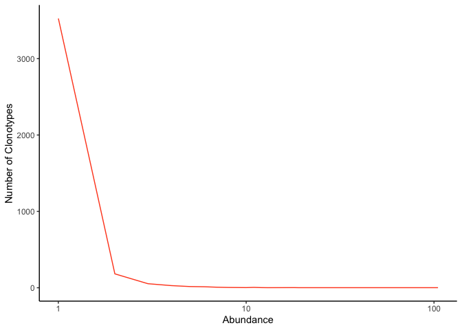

```r
abundanceContig(vdj, cloneCall = "gene", group = "sample", scale = FALSE) +
  guides(color = "none")
```

```r
abundanceContig(vdj, cloneCall = "gene", group = "sample", scale = FALSE, exportTable = TRUE) %>%
  arrange(desc(Abundance)) %>%
  filter(!is.na(CTgene)) %>%
  select(CTgene, Abundance) %>%
  slice(1:20) %>%
  kable() %>%
  kable_styling(bootstrap_options = c("striped", "hover", "responsive"), fixed_thead = TRUE)
```

| CTgene | Abundance |
| --- | --- |
| TRAV25.TRAJ37.TRAC_TRBV6-5.TRBJ1-1.None.TRBC1 | 98 |
| NA_TRBV6-5.TRBJ1-1.None.TRBC1 | 44 |
| NA_TRBV7-2.TRBJ2-3.None.TRBC2 | 39 |
| TRAV9-2.TRAJ7.TRAC_TRBV7-2.TRBJ2-3.None.TRBC2 | 33 |
| NA_TRBV20-1.TRBJ2-7.None.TRBC2 | 19 |
| NA_TRBV7-9.TRBJ2-2.None.TRBC2 | 18 |
| TRAV12-2.TRAJ33.TRAC_TRBV4-1.TRBJ1-5.None.TRBC1 | 18 |
| NA_TRBV20-1.TRBJ2-1.None.TRBC2 | 13 |
| NA_TRBV7-2.TRBJ2-7.None.TRBC2 | 12 |
| TRAV12-2.TRAJ20.TRAC_TRBV6-2.TRBJ2-1.None.TRBC2 | 12 |
| NA_TRBV20-1.TRBJ1-2.None.TRBC1 | 11 |
| NA_TRBV5-1.TRBJ2-1.None.TRBC2 | 11 |
| TRAV1-2.TRAJ15.TRAC_TRBV7-9.TRBJ1-2.None.TRBC1 | 11 |
| TRAV12-2.TRAJ31.TRAC_TRBV9.TRBJ2-5.None.TRBC2 | 11 |
| TRAV4.TRAJ30.TRAC_TRBV7-9.TRBJ2-2.None.TRBC2 | 11 |
| NA_TRBV5-1.TRBJ2-3.None.TRBC2 | 10 |
| NA_TRBV9.TRBJ2-1.None.TRBC2 | 10 |
| NA_TRBV20-1.TRBJ1-1.None.TRBC1 | 9 |
| NA_TRBV20-1.TRBJ2-3.None.TRBC2 | 9 |
| NA_TRBV3-1.TRBJ2-7.None.TRBC2 | 9 |

## Contig length distribution

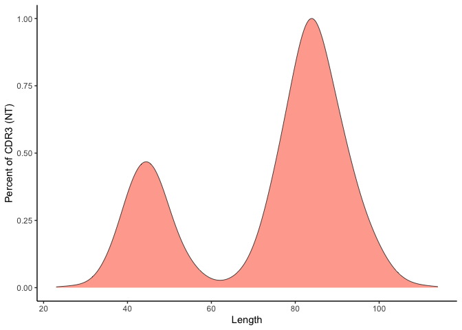

```r
lengthContig(vdj, cloneCall="nt", scale=TRUE, chains = "combined", group="sample") +
  guides(fill = "none")
```

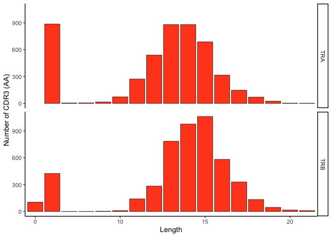

```r
lengthContig(vdj, cloneCall="aa", chains = "single", group = "sample") +
  guides(fill = "none")
```

### Shared clonotypes

This function does not make much sense with only one sample, and is included just for the purposes of demonstration. We’ll come back to it later after using the gene expression data to separate our V(D)J pool into separate samples.

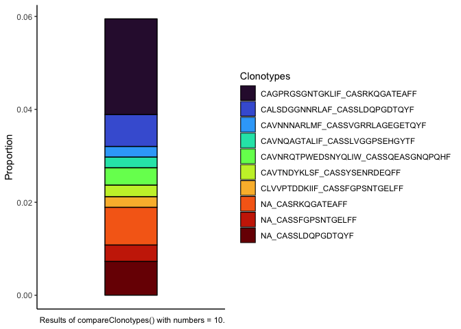

```r
compareClonotypes(vdj, numbers = 10, cloneCall = "aa", graph = "alluvial") +
  theme(axis.text.x = element_text(angle = 45, hjust = 1)) +
  scale_fill_viridis_d(option = "turbo") +
  labs(caption = "Results of compareClonotypes() with numbers = 10.") +
  theme(axis.text.x = element_blank(),
        axis.ticks.x = element_blank())
```

### Relative abundance of clones by frequency

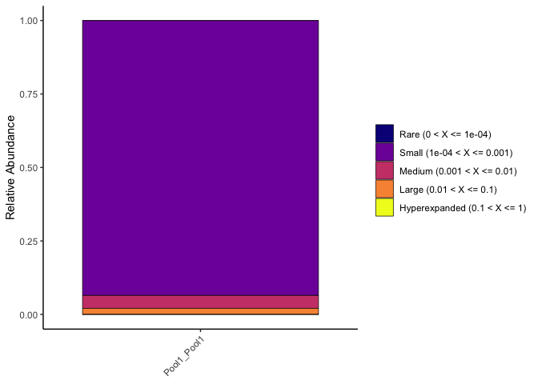

```r
clonalHomeostasis(vdj, cloneCall = "aa") +
  scale_fill_viridis_d(option = "plasma") +
  theme(axis.text.x = element_text(angle = 45, hjust = 1),
        axis.title.x = element_blank(),
        legend.title = element_blank())
```

### Relative abundance of clones by index

Clonal index 1 represents the most frequent clone in a given sample, while index 1000 represents the 1000th most frequent clone.

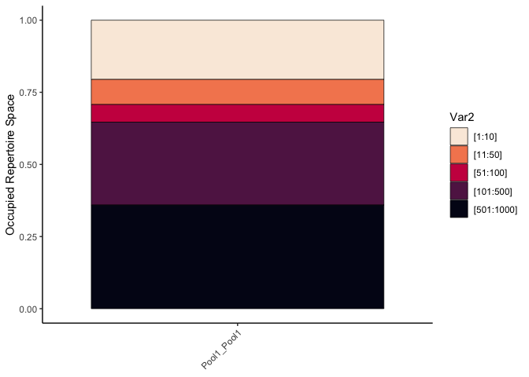

```r
clonalProportion(vdj, cloneCall = "aa", split = c(10, 50, 100, 500, 1000)) +
  scale_fill_viridis_d(option = "rocket", direction = -1) +
  theme(axis.text.x = element_text(angle = 45, hjust = 1),
        axis.title.x = element_blank())
```

### Overlap analysis

Clonal overlap is scaled to the number of unique clonotypes in the smaller sample. This code errors on fewer than two samples. Again, we will revisit this function after splitting our V(D)J data into multiple samles using the gene expression data.

```r
clonalOverlap(vdj, cloneCall = "gene+nt")
```

## Clonal diversity

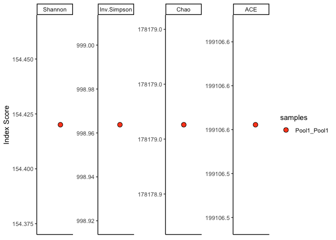

```r
clonalDiversity(vdj, cloneCall = "aa", group = "samples")
```

## TCR clustering

This is slow. I suggest skipping it for now so that you don’t get stuck at this point.

```r
tcr.clusters <- clusterTCR(vdj[[1]], chain = "TCRA", sequence = "aa", threshold = 0.9)
```

## Combine V(D)J and expression data

First, we need to download the expression data. The Seurat object located in the vdj_workshop directory on tadpole contains a subset of the data from the study, re-analyzed with different parameters.

```bash
scp username@tadpole.genomecenter.ucdavis.edu:/share/workshop/vdj_workshop/R_objects/seurat_object.rds .
```

```r
library(Seurat)
expression <- readRDS("seurat_object.rds")
expression <- RenameCells(expression, new.names = expression$barcode)
vdj <- lapply(vdj, function (x) {
  b = sapply(strsplit(sapply(strsplit(x$barcode, split = "_"), "[[", 3), split = "-"), "[[", 1)
  x$barcode = b
  x
  })
expression <- combineExpression(vdj, expression, cloneCall="gene")
head(expression@meta.data) %>%
  kable() %>%
  kable_styling(bootstrap_options = c("striped", "hover", "responsive"))
```

|  | orig.ident | nCount_RNA | nFeature_RNA | Convalescent | Antigen | percent.mito | S.Score | G2M.Score | Phase | barcode | CTgene | CTnt | CTaa | CTstrict | Frequency | cloneType |
| --- | --- | --- | --- | --- | --- | --- | --- | --- | --- | --- | --- | --- | --- | --- | --- | --- |
| AAACCTGAGACTAGAT | Pool1 | 17521 | 3471 | Covid convelescent | COVID | 0.5878660 | -0.6721786 | -0.2657356 | G1 | NA | NA | NA | NA | NA | NA | NA |
| AAACCTGAGCAAATCA | Pool1 | 16648 | 3690 | Covid convelescent | Tdap | 1.6518501 | -0.2915326 | -0.0625301 | G1 | AAACCTGAGCAAATCA | TRAV12-1.TRAJ10.TRAC_TRBV2.TRBJ2-2.None.TRBC2 | TGTGTGGTGAACACGGGAGGAGGAAACAAACTCACCTTT_TGTGCCAGCAGCGCCGGGACCGGGGAGCTGTTTTTT | CVVNTGGGNKLTF_CASSAGTGELFF | TRAV12-1.TRAJ10.TRAC_TGTGTGGTGAACACGGGAGGAGGAAACAAACTCACCTTT_TRBV2.TRBJ2-2.None.TRBC2_TGTGCCAGCAGCGCCGGGACCGGGGAGCTGTTTTTT | 0.0002657 | Small (1e-04 < X <= 0.001) |
| AAACCTGAGCTACCTA | Pool1 | 16250 | 3664 | Covid convelescent | COVID | 0.4307692 | -0.2961077 | -0.2611317 | G1 | AAACCTGAGCTACCTA | TRAV17.TRAJ9.TRAC_TRBV20-1.TRBJ1-4.None.TRBC1 | TGTGCTACGGACGCGCGGGCTGGAGGCTTCAAAACTATCTTT_TGCAGTGCTAGAGATCTGGGACAGCGTGAAAAACTGTTTTTT | CATDARAGGFKTIF_CSARDLGQREKLFF | TRAV17.TRAJ9.TRAC_TGTGCTACGGACGCGCGGGCTGGAGGCTTCAAAACTATCTTT_TRBV20-1.TRBJ1-4.None.TRBC1_TGCAGTGCTAGAGATCTGGGACAGCGTGAAAAACTGTTTTTT | 0.0002657 | Small (1e-04 < X <= 0.001) |
| AAACCTGAGTACGCGA | Pool1 | 10911 | 2630 | Covid convelescent | MMR | 0.5499038 | -0.4055037 | -0.2255377 | G1 | AAACCTGAGTACGCGA | TRAV6.TRAJ45.TRAC_NA | TGTGCTCTAGACATGGCGTATTCAGGAGGAGGTGCTGACGGACTCACCTTT_NA | CALDMAYSGGGADGLTF_NA | TRAV6.TRAJ45.TRAC_TGTGCTCTAGACATGGCGTATTCAGGAGGAGGTGCTGACGGACTCACCTTT_NA_NA | 0.0002657 | Small (1e-04 < X <= 0.001) |
| AAACCTGCAGACTCGC | Pool1 | 7321 | 2560 | Covid convelescent | COVID | 0.3824614 | -0.4477389 | -0.2590875 | G1 | NA | NA | NA | NA | NA | NA | NA |
| AAACCTGCATCCCATC | Pool1 | 2539 | 1100 | Uninfected Control | COVID | 6.7349350 | -0.1436077 | -0.0747784 | G1 | AAACCTGCATCCCATC | TRAV13-2.TRAJ30.TRAC_TRBV19.TRBJ1-1.None.TRBC1 | TGTGCAGAGAACAGAGATGACAAGATCATCTTT_TGTGCCAGTACTTTCTCTGACTCGGGCGGCACTGAAGCTTTCTTT | CAENRDDKIIF_CASTFSDSGGTEAFF | TRAV13-2.TRAJ30.TRAC_TGTGCAGAGAACAGAGATGACAAGATCATCTTT_TRBV19.TRBJ1-1.None.TRBC1_TGTGCCAGTACTTTCTCTGACTCGGGCGGCACTGAAGCTTTCTTT | 0.0015945 | Medium (0.001 < X <= 0.01) |

### Find markers for “large” clones

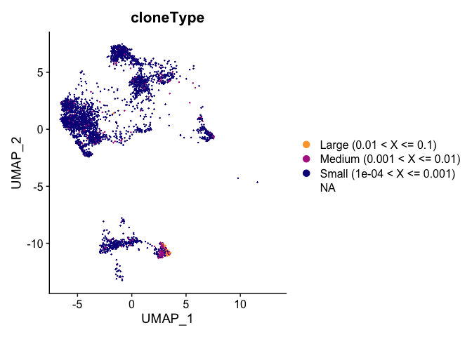

```r
DimPlot(expression, group.by = "cloneType") +
  scale_color_viridis_d(option = "plasma", direction = -1, end = 0.8)
```

```r
Idents(expression) <- "cloneType"
large.markers <-FindMarkers(expression, ident.1 = "Large (0.01 < X <= 0.1)")
head(large.markers) %>%
  kable() %>%
  kable_styling(bootstrap_options = c("striped", "hover", "responsive"))
```

|  | p_val | avg_log2FC | pct.1 | pct.2 | p_val_adj |
| --- | --- | --- | --- | --- | --- |
| TRAV25 | 0 | 3.2596638 | 0.969 | 0.033 | 0 |
| TRBV6-5 | 0 | 3.9298640 | 0.984 | 0.065 | 0 |
| NXPH4 | 0 | 1.7354687 | 0.359 | 0.009 | 0 |
| AC020659.1 | 0 | 1.2105106 | 0.281 | 0.006 | 0 |
| TRBV12-5 | 0 | 1.0929780 | 0.250 | 0.005 | 0 |
| CRYBG2 | 0 | 0.9937289 | 0.188 | 0.003 | 0 |

```r
Idents(expression) <- "Antigen"
```

### Split V(D)J data into separate samples and re-run scRepertoire functions

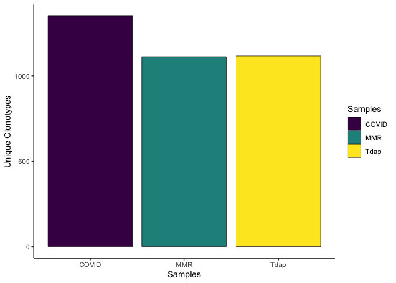

```r
vdj <- expression2List(expression, group = "Antigen")

quantContig(vdj, cloneCall="aa", scale = FALSE) +
  scale_fill_viridis_d()
```

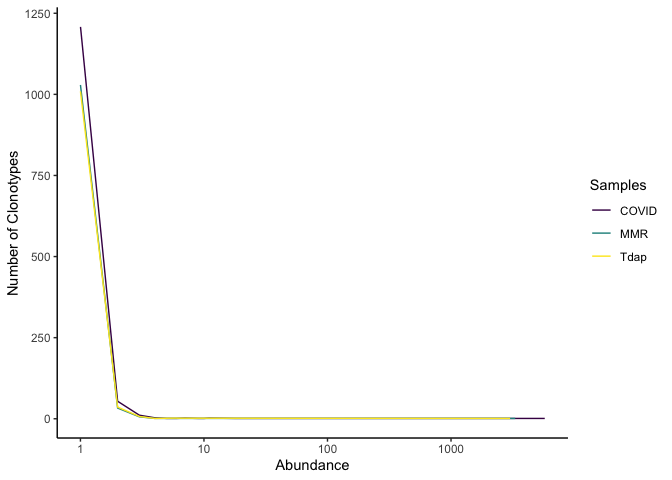

```r
abundanceContig(vdj, cloneCall = "gene", scale = FALSE) +
  scale_color_viridis_d()
```

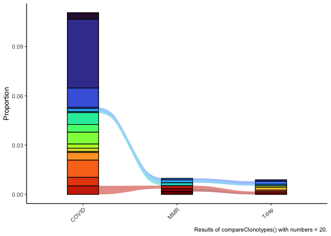

```r
compareClonotypes(vdj, numbers = 20, cloneCall = "aa", graph = "alluvial") +
  scale_fill_viridis_d(option = "turbo") +
  guides(fill = "none") +
  theme(axis.text.x = element_text(angle = 45, hjust = 1)) +
  labs(caption = "Results of compareClonotypes() with numbers = 20.")
```

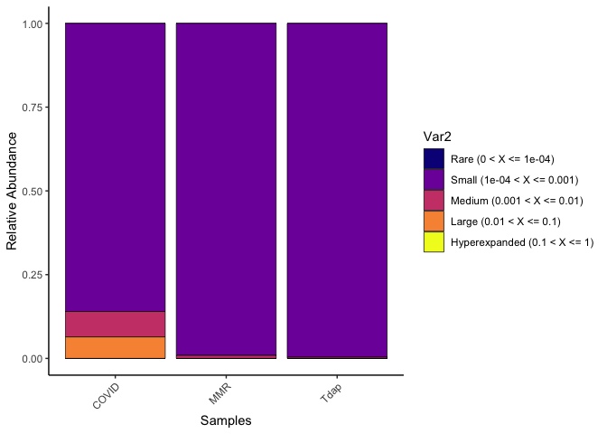

```r
clonalHomeostasis(vdj, cloneCall = "aa") +
  scale_fill_viridis_d(option = "plasma") +
  theme(axis.text.x = element_text(angle = 45, hjust = 1))
```

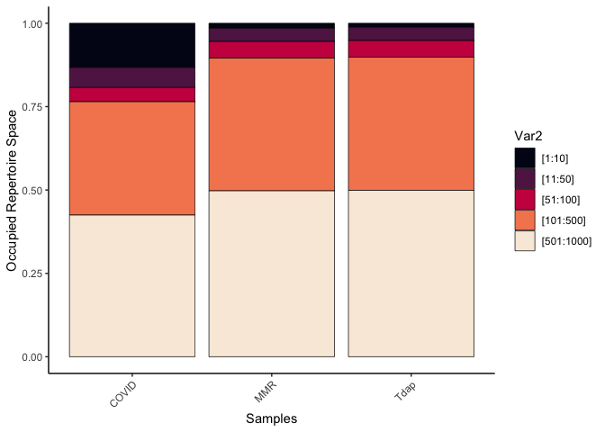

```r
clonalProportion(vdj, cloneCall = "aa", split = c(10, 50, 100, 500, 1000)) +
  scale_fill_viridis_d(option = "rocket") +
  theme(axis.text.x = element_text(angle = 45, hjust = 1))
```

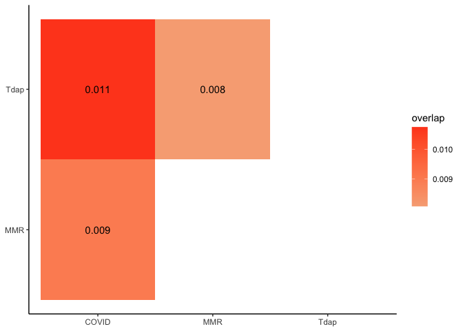

```r
clonalOverlap(vdj, cloneCall = "gene+nt")
```

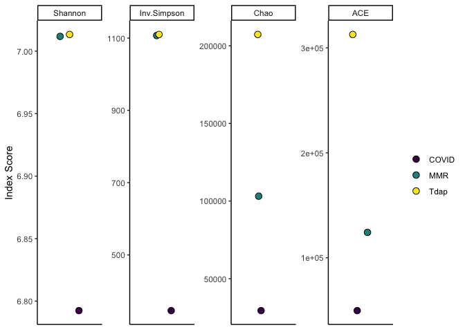

```r
clonalDiversity(vdj, cloneCall = "aa") +
  scale_fill_viridis_d() +
  theme(legend.title = element_blank())
```

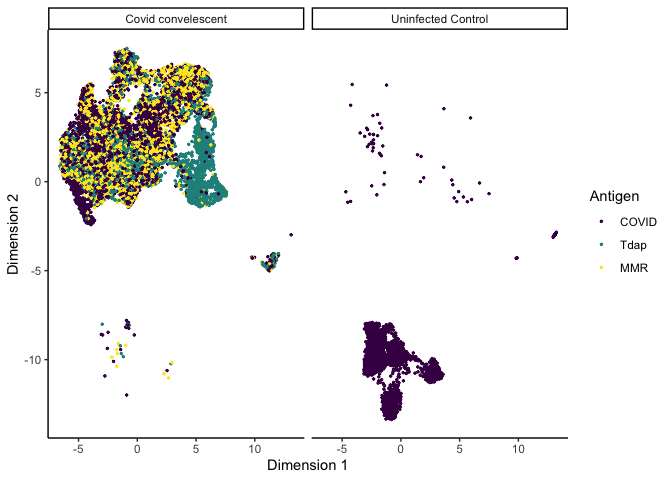

```r
clonalOverlay(expression,
              reduction = "umap",
              freq.cutpoint = 30,
              bins = 10,
              facet = "Convalescent") +
  labs(color = "Antigen") +
  scale_color_viridis_d()
```

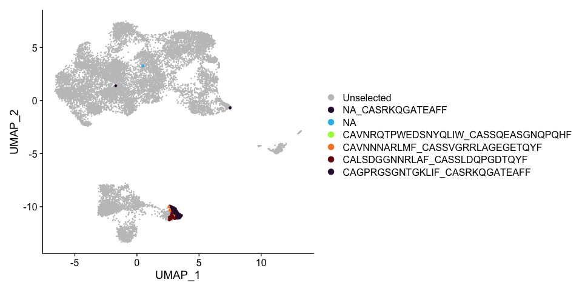

```r
contig <- abundanceContig(vdj, cloneCall = "aa", exportTable = TRUE) %>%
  arrange(desc(Abundance)) %>%
  filter(!is.na(CTaa)) %>%
  slice(1:5)
Idents(expression) <- expression$CTaa
DimPlot(expression,
        reduction = "umap",
        cells.highlight = CellsByIdentities(expression, idents = contig$CTaa),
        cols.highlight = turbo(length(contig$CTaa)))
```

## Circos plots

This code is under construction! If we have time, I will attempt to update this and run it.

```r
?getCirclize
circles <- getCirclize(vdj, groupBy = "orig.ident")

#Just assigning the normal colors to each cluster
grid.cols <- hue_pal()(length(unique(seurat$orig.ident)))
names(grid.cols) <- levels(seurat$orig.ident)

#Graphing the chord diagram
chordDiagram(circles, self.link = 1, grid.col = grid.cols)

data_to_circlize <- experiment.aggregate[[]][experiment.aggregate$RNA_snn_res.0.75 %in% b_cells & !is.na(experiment.aggregate$CTgene),]
dim(data_to_circlize)
head(data_to_circlize)

aa_seqs <- strsplit(as.character(unlist(data_to_circlize$CTaa)),split="_")
table(sapply(aa_seqs, length))
data_to_circlize$A_chain = sapply(aa_seqs, "[[", 1L)
data_to_circlize$B_chain = sapply(aa_seqs, "[[", 2L)

data_to_circlize$IGH = sapply(strsplit(data_to_circlize$CTstrict, split="_"), function(x) paste(unique(x[c(1)]),collapse="_"))
data_to_circlize$IGL = sapply(strsplit(data_to_circlize$CTstrict, split="_"), function(x) paste(unique(x[c(3)]),collapse="_"))

# get optimal sequence order from trivial plot
chordDiagram(data.frame(data_to_circlize$IGH[1:15], data_to_circlize$IGL[1:15], times = 1), annotationTrack = "grid" )
seq.order <- get.all.sector.index()
circos.clear()
```